# Final Report: Predicting e-cigarette usage amongst California teenagers

rl2999

12/15/2018

# Background and Literature Review

E-cigarettes and vaping are particularly powerful for teens and young people today; the novelty and newness of both have made the topic ripe for media panic. Some scholars have examined Judith Butler’s notion of performativity (famously used to examine gender as a socially mediated performance) in application to the growing popularity of e-cigarettes and vaporizers, arguing that the present contestation of social values and perceptions regarding use of e-cigarettes and vaporizers indicates a critical present moment in which policy intervention to denormalize the practice could be an effective possibility (Lucherini, Rooke, and Amos 2018).

While Lucherini notes that decades of anti-smoking campaigns, labelling, tax increases, and other strategies to denormalize the practice of smoking, e-cigarettes and vaporizer usage presents itself as a practice distanced from cigarette usage, providing a new frontier of contested public social meanings. Knowing that e-cigarettes are another form of nicotine consumption, this contested perception of e-cigarettes and vaporizers is noted in a North Carolina study in which a large proportion of participants perceived e-cigs as “healthy” (Anand et al. 2015).

## Rising popularity of e-cigarettes

With this framework in mind, it is no surprise that e-cigarettes have become reported as extremely popular amongst adolescents who are not only socially impressionable but are also likely to become dependent on nicotine as a result of their developing physiology. The JUUL company, which produces and sells the JUUL e-cigarette infamous for its teenage appeal, currently captures 70% of the e-cigarette market share in the US. The company recently ceased sales of most of its flavored refill pods—creme, mango, and fruit— over increasing pressures from the FDA over the concern of e-cigarettes becoming prevalent amongst teenagers (Kaplan and Hoffman 2018).

One aspect of the JUUL device that separates it from early e-cigarette products is the industrial design—its sleek, slim, rectangular profile is often compared to that of a USB flash drive, making it relatively inconspicuous and easy to conceal. Also, the device itself produces an odorless aerosol mist that quickly dissipates, lending itself well to being used in schools and environments where traditional cigarettes could not be used (Kaplan and Hoffman 2018). According to CNBC’s reporting on CDC data, roughly 20% of high schoolers are estimated to use e-cigarettes (LaVito 2018).

## Types of predictors identified in other quantitative studies

A range of studies have been carried out about factors relating to e-cigarettes. One study found that gender, educational attainment, and geographic region were not significantly associated with e-cigarette usage (Giovenco, Lewis, and Delnevo 2014). Neighborhood problems were associated with a 11%, 16%, and 25% higher odds of alcohol, marijuana, and e-cigarette use. Neighborhood disorganization was associated with 59% higher odds, while higher units of neighborhood social cohesion was associated with 17% lower odds of e-cig use. This study also reported that objective measures of socioeconomic disadvantage were not associated with any outcomes (Shih et al. 2017). One study from Scotland reported that “hanging around in the street” more than 1 time a week reported an odds ratio of 4.34 in regard to trying e-cigarettes, suggesting that this may be a proxy indicator of low levels of adult supervision, which the authors note has been associated with other adolescent risk activities (Best et al. 2016). The same study noted that social networks play an important role in association, with young people who reported having a best friend who smoke having an odds ratio of over 3.3 in their models (Best et al. 2016). The North Carolina high schooler study with 2,769 respondents found positive associations with older age, tobacco use, male gender, white, use of e-cigarette by mother, parental tobacco use, and lower academic performance, while finding negative association with not knowing e-cigarette users and living with the mother (Anand et al. 2015 +).

# Hypothesis and variables

Based on my literature review of prior studies, along with the operative data set I have chosen, my hypothesis is that the following social factors will be significant:

*sochs_p1*: SOCIAL COHESION NEIGHBORHOOD SCALE, which I hypothesize is relevant as it represents the generalization of various survey responses related to neighborhood perceptions, which was noted in a previous study as being significant (Shih et al. 2017). *TE22*: EVER HAD MORE THAN FEW SIPS OF ALCOHOLIC DRINK, which I hypothesize will be significant, since risk behaviors are popularly hypothesized to associated with each other, *TD43*: RULES IN HOME FOR TURNING OFF OR PUTTING AWAY D-5 ELECTRONICS, which I hypothesize will be significant because previous studies have noted adult supervision as having a negative association with risk behaviors (Best et al. 2016).

In addition, I hypothesize that the following demographic variables will also be significant: *SRAGE_P AGE*: since I hypothesize that older ages may be more likely to partake in e-cigarette usage.

My prediction variable is *TE66*: EVER SMOKED ELECTRONIC CIGARETTES.

Thus, the equation for my model resembles $te66 = sochs_p1 + te22 + td43 + srage_p$

# Methodology

I will use rudimentary multiple logistic regression to analyze the CHIS 2017 Teen survey data to build a model that incorporates elements of social cohesion and demographics to assess statistically significant variables identified in other studies.

I sourced the data from the California Health Interview Survey 2017 teen dataset. The data was collected by the UCLA Center for Health Policy Research, the California Department of Public Health, and the Department of Health Care Services, and contains survey questions about lifestyle, insurance coverage, mental health, neighborhood social cohesion— among various other topics pertaining to public health. The data was collected for decision making on public health policy.

Source: http://healthpolicy.ucla.edu/chis/

In terms of methodology, the CHIS data was gathered by random-digit-dial samples of both landline and cellular phones in California, divided into several sampling strata. In each stratum, residential phone numbers were dialed, and 1 adult was randomly selected in each household, along with one1 child and adolescent. There were a total of 448 teenagers interviewed in this data in 2017, with 51% from the cell phone sample. The samples were weighted in order to create population estimates and compensate for the bias in the survey design methodology (Dutwin et al. 2018.)

Because this survey data was gathered through a complex design, we utilize the survey package for R, which allows us to estimate population totals and means, and use these estimates to create models (Lumley 2011).

```r
# CHIS_sr <-
#   svrepdesign(
#     data = CHIS_r,
#     variables = CHIS_r,
#     weight = CHIS_2017_teen$rakedw0,
#     scale = 1,
#     rscales = 1,
#     repweights = "rakedw[1-9]+" ,
#     type = "other",
#     combined.weights = TRUE
#   )

#svytotal(~te66 %>% as_factor(), design = CHIS)
```

# Descriptive Statistics

## Descriptive stats for te66; smoked e-cigarettes

https://uc-r.github.io/descriptives_categorical

```r
table(CHIS_2017_teen$te66)
```

```
##
##   1   2
##  40 408
```

```r
prop.table(table(CHIS_2017_teen$te66 %>% as_factor()))
```

```
##
##                    NOT ASCERTAINED                         DON'T KNOW
##                         0.00000000                         0.00000000
##                            REFUSED ADULT/HOUSEHOLD INFO NOT COLLECTED
##                         0.00000000                         0.00000000
##                      PROXY SKIPPED                       INAPPLICABLE
##                         0.00000000                         0.00000000
##                                YES                                 NO
##                         0.08928571                         0.91071429
```

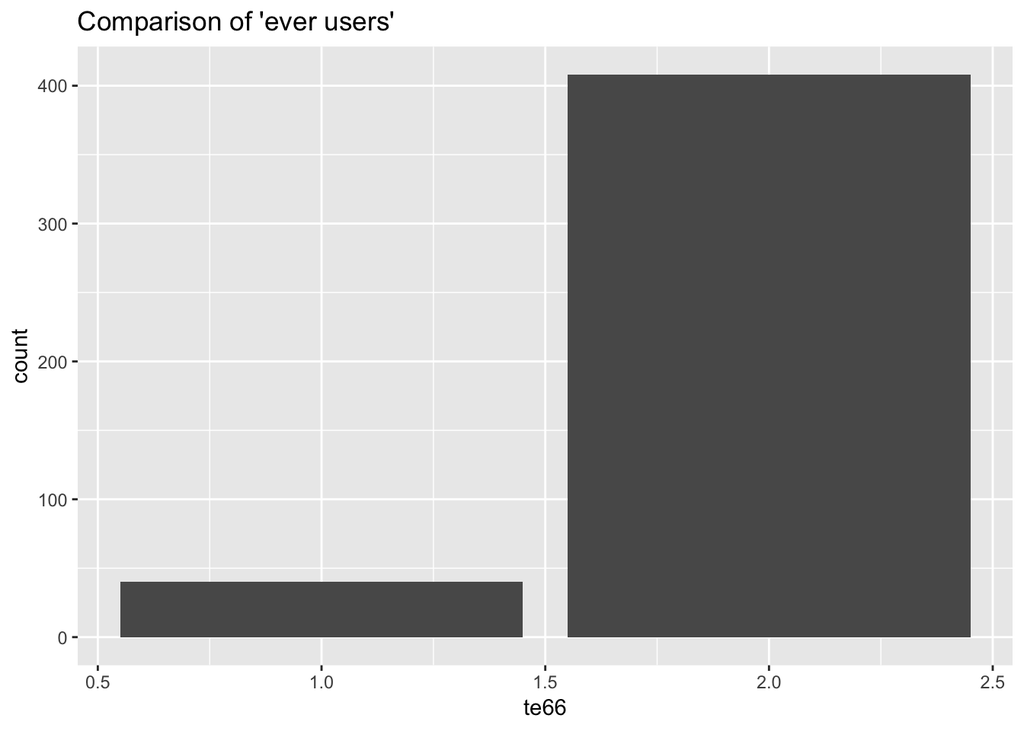

```r
ggplot(
  CHIS_2017_teen,
  aes(x = te66)) +
  geom_bar() +
  ggtitle("Comparison of 'ever users'")
```

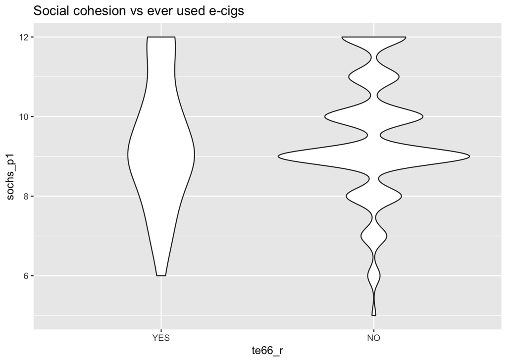

```r
## Social cohesion vs ever users
CHIS_r %>% ggplot(
  aes(y = sochs_p1, x = te66_r)) +
  geom_violin() + ggtitle("Social cohesion vs ever used e-cigs")
```

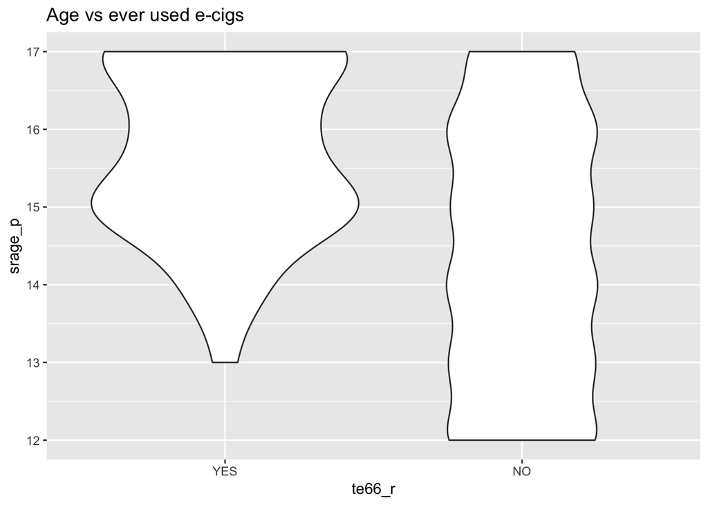

```r
## Age vs ever users
CHIS_r %>% ggplot(aes(y = srage_p, x = te66_r)) +
  geom_violin() + ggtitle("Age vs ever used e-cigs")
```

# Power analysis

```r
pwr.f2.test(
  f2 = NULL,
  u = 40,
  v = 448,
  sig.level = 0.05,
  power = 0.8
)
```

```
##
##      Multiple regression power calculation
##
##               u = 40
##               v = 448
##              f2 = 0.0598719
##       sig.level = 0.05
##           power = 0.8
```

# Model Results

To create a logistical regression on e-cigarette usage, which is a discrete binary outcome of 0 and 1, I follow Lumley’s suggestion to use the quasibinomial family in the glm package (Lumley 2011).

```r
# Create a new complex survey object that considers the survey weights. Adapted from Lumley.
CHIS_sr <-
  svrepdesign(
    data = CHIS_r,
    variables = CHIS_r,
    weight = CHIS_2017_teen$rakedw0,
    scale = 1,
    rscales = 1,
    repweights = "rakedw[1-9]+" ,
    type = "other",
    combined.weights = TRUE
  )

# This attempt uses quasibinomial family and considers survey design. However, I
# deviate from Lumley's suggestion of using quasibinomial family parameter since
# quasibinomial does not report log likelihood.
```

```r
mod1 <-
  svyglm(
    design = CHIS_sr,
    formula =
      te66_r ~ sochs_p1 + te22_r + td43_r + srage_p,
    na.action = "na.pass",
    family = binomial
  )
```

```r
mod2 <-
  svyglm(
    design = CHIS_sr,
    formula =
      te66_r ~ sochs_p1 + te22_r + td43_r + srage_p,
    na.action = "na.pass",
    family = quasibinomial(link = 'logit')
  )
summary(mod1, correlation = TRUE)
```

```
##
## Call:
## svyglm(design = CHIS_sr, formula = te66_r ~ sochs_p1 + te22_r +
##     td43_r + srage_p, na.action = "na.pass", family = binomial)
##
## Survey design:
## svrepdesign.default(data = CHIS_r, variables = CHIS_r, weight = CHIS_2017_teen$rakedw0,
##     scale = 1, rscales = 1, repweights = "rakedw[1-9]+", type = "other",
##     combined.weights = TRUE)
##
## Coefficients:
##             Estimate Std. Error t value Pr(>|t|)
## (Intercept)  30.5345     6.7085   4.552 2.05e-05 ***
## sochs_p1     -0.2725     0.2638  -1.033  0.30510
## te22_rYES   -16.1508     3.6189  -4.463 2.84e-05 ***
## te22_rNO    -14.8061     3.4531  -4.288 5.37e-05 ***
## td43_rNO      0.4839     0.7013   0.690  0.49237
## srage_p      -0.6959     0.2175  -3.199  0.00203 **
## ---
## Signif. codes:  0 '***' 0.001 '**' 0.01 '*' 0.05 '.' 0.1 ' ' 1
##
## (Dispersion parameter for binomial family taken to be 439.4501)
##
## Number of Fisher Scoring iterations: 16
##
## Correlation of Coefficients:
##           (Intercept) sochs_p1 te22_rYES te22_rNO td43_rNO
## sochs_p1  -0.74
## te22_rYES -0.66        0.22
## te22_rNO  -0.59        0.12     0.98
## td43_rNO   0.11       -0.06    -0.19     -0.15
## srage_p   -0.76        0.53     0.10      0.06    -0.06
```

```r
# Exponentiated coefficients
exp(mod2$coefficients)
```

```
##  (Intercept)     sochs_p1    te22_rYES     te22_rNO     td43_rNO
## 1.823795e+13 7.615065e-01 9.678576e-08 3.713742e-07 1.622312e+00
##      srage_p
## 4.986435e-01
```

```r
# Convert coefficients logits to probabilities.
exp(mod2$coefficients)/(1+exp(mod2$coefficients))
```

```
##  (Intercept)     sochs_p1    te22_rYES     te22_rNO     td43_rNO
## 1.000000e+00 4.323041e-01 9.678575e-08 3.713740e-07 6.186571e-01
##      srage_p
## 3.327299e-01
```

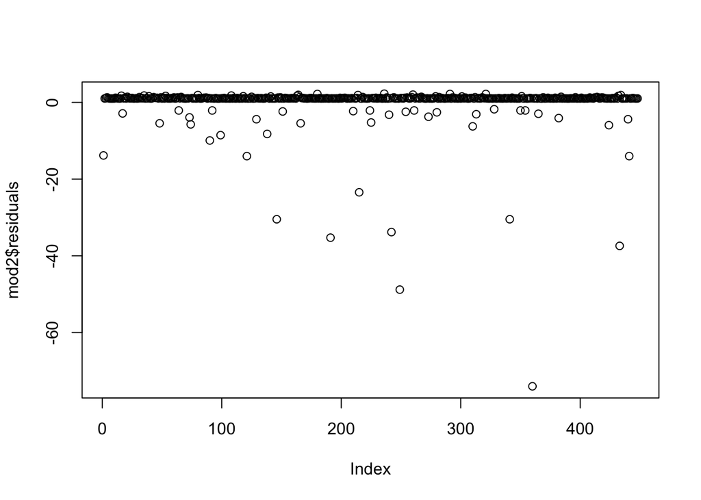

```r
plot(mod2$residuals)
```

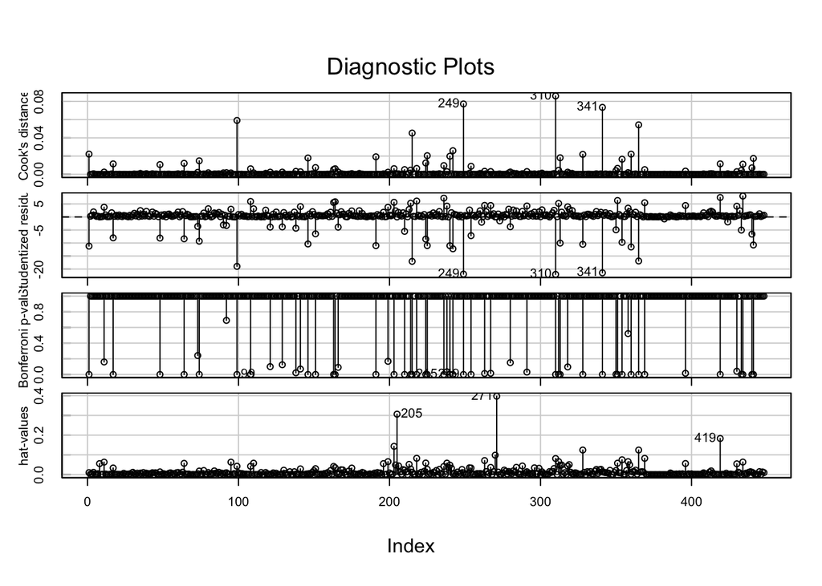

```r
#QQ Plot
#qqplot(mod2, id = list(n=3))
# QQ plot is a quantile-quantile plot, shows if residuals are normally distributed.
influenceIndexPlot(mod2, id=list(n = 3))
```

```r
#plot(predictorEffects(mod2))
```

# Results of analysis

The variables that show up as significant are *te_22_rYES*, *te_22_rNO* and *srage_p*. Although statistically significant in tests, the values for *te_22_RYES* are extremely low, suggesting a negligible substantive influence on odds. I suspect that *te22_r* reports YES and NO as significant since there is another factor level “INAPPLICABLE” that may be generating these results. However, recoding this extraneous factor to NA’s does not resolve the issue, suggesting that there may be an idiosyncracy between my predictor te66 and te22 resulting in all factor levels of te22 being flagged as significant under the 0 level.

# Difficulties assessing fit

```r
# Can't get McFadden's R squared
#pR2(object = mod1)
regTermTest(mod1, ~sochs_p1 + ~te22_r + ~td43_r + ~srage_p)
```

```
## Wald test for sochs_p1 te22_r td43_r srage_p
##  in svyglm(design = CHIS_sr, formula = te66_r ~ sochs_p1 + te22_r +
##     td43_r + srage_p, na.action = "na.pass", family = binomial)
## F =  6.127643  on  5  and  74  df: p= 8.392e-05
```

```r
regTermTest(mod1, ~srage_p)
```

```
## Wald test for srage_p
##  in svyglm(design = CHIS_sr, formula = te66_r ~ sochs_p1 + te22_r +
##     td43_r + srage_p, na.action = "na.pass", family = binomial)
## F =  10.23647  on  1  and  74  df: p= 0.0020283
```

```r
AIC(mod1)
```

```
##     eff.p       AIC  deltabar
##  13.50060 238.00459   2.70012
```

```r
AIC(mod2)
```

```
##     eff.p       AIC  deltabar
##  13.50060 238.00459   2.70012
```

```r
anova(mod2, test = "Chisq")
```

```
## Anova table:  (Rao-Scott LRT)
## svyglm(design = CHIS_sr, formula = te66_r ~ sochs_p1, na.action = "na.pass",
##     family = quasibinomial(link = "logit"))
##            stats     DEff df         p
## sochs_p1  1.2030  3.32270  1 0.5442569
## te22_r   32.5415  2.16010  2 0.0063869 **
## td43_r    0.4031  3.02020  1 0.7087466
## srage_p  27.4742  2.07700  1 0.0002959 ***
## ---
## Signif. codes:  0 '***' 0.001 '**' 0.01 '*' 0.05 '.' 0.1 ' ' 1
```

```r
# For some reason, both models cannot be compared
#anova(mod1, mod2 test = "Chisq")
vif(mod2)
```

```
##              GVIF Df GVIF^(1/(2*Df))
## sochs_p1 1.790800  1        1.338208
## te22_r   1.440633  2        1.095565
## td43_r   1.075465  1        1.037046
## srage_p  1.397258  1        1.182057
```

```r
outlierTest(mod2)
```

```
##      rstudent unadjusted p-value Bonferonni p
## 310 -22.05796         5.1682e-34   2.3154e-31
## 249 -21.94150         7.2356e-34   3.2416e-31
## 341 -21.45244         3.0160e-33   1.3512e-30
## 99  -18.98043         5.9948e-30   2.6857e-27
## 215 -17.05388         3.5831e-27   1.6052e-24
## 365 -16.90567         5.9677e-27   2.6735e-24
## 242 -12.22363         2.4662e-19   1.1049e-16
## 360 -11.53871         4.0255e-18   1.8034e-15
## 1   -11.19121         1.6933e-17   7.5862e-15
## 240 -11.04193         3.1511e-17   1.4117e-14
```

Lumley suggests Wald test to test the hypothesis that the added terms are zero; in other words, if the terms have any effect on the model (Lumley 2011)(p.113).

# Results

My initial hypothesis was rejected, since the only variable that seemed substantively significant was age, which was noted in the Anand study as positively associated (Anand et al. 2015 +). There did not seem to be associated with any of the other variables included in my model, and the variable describing alcohol use only had an extremely small coefficient and resulting probability, which may not substantively hold.

# References

Anand, Vivek, Kaye L. McGinty, Kevin O’Brien, Gregory Guenthner, Ellen Hahn, and Catherine A. Martin. 2015. “E-Cigarette Use and Beliefs Among Urban Public High School Students in North Carolina.” *Journal of Adolescent Health* 57 (1): 46–51. https://doi.org/10.1016/j.jadohealth.2015.03.018.

Ballard, Robert. n.d. “Using the R-Squared Statistic in ANOVA and GLMs iSixSigma.” Accessed December 17, 2018. https://www.isixsigma.com/tools-templates/regression/using-the-r-squared-statistic-in-anova-and-general-linear-models/.

Best, C., W. van der Sluijs, F. Haseen, D. Eadie, M. Stead, A. M. MacKintosh, J. Pearce, et al. 2016. “Does Exposure to Cigarette Brands Increase the Likelihood of Adolescent E-Cigarette Use? A Cross-Sectional Study.” *BMJ Open; London* 6 (2). https://doi.org/http://dx.doi.org/10.1136/bmjopen-2015-008734.

Bolker, Ben. 2017. “Dealing with Quasi- Models in R,” October, 5. https://cran.r-project.org/web/packages/bbmle/vignettes/quasi.pdf.

Dutwin, David, Susan Sherr, Arina Goyle, Jonathan Best, and Kathy Langdale. 2018. “CHIS 2017 Methodology Report Series - Sample Design,” October, 65. http://healthpolicy.ucla.edu/chis/design/Documents/CHIS_2017_MethodologyReport1_SampleDesign.pdf.

Giovenco, Daniel P., M. Jane Lewis, and Cristine D. Delnevo. 2014. “Factors Associated with E-Cigarette Use: A National Population Survey of Current and Former Smokers.” *American Journal of Preventive Medicine* 47 (4): 476–80. https://doi.org/10.1016/j.amepre.2014.04.009.

Kaplan, Sheila, and Jan Hoffman. 2018. “Juul Suspends Selling Most E-Cigarette Flavors in Stores.” *The New York Times*, November. https://www.nytimes.com/2018/11/13/health/juul-ecigarettes-vaping-teenagers.html.

LaVito, Angelica. 2018. “FDA Seizes Documents in Surprise Inspection of E-Cigarette Maker Juul.” October 2, 2018. https://www.cnbc.com/2018/10/02/fda-seizes-documents-in-surprise-inspection-of-e-cigarette-maker-juul.html.

Lucherini, Mark, Catriona Rooke, and Amanda Amos. 2018. “E-Cigarettes, Vaping and Performativity in the Context of Tobacco Denormalisation.” *Sociology of Health & Illness* 40 (6): 1037–52. https://doi.org/10.1111/1467-9566.12741.

Lumley, Thomas. 2011. *Complex Surveys: A Guide to Analysis Using R*. Vol. 565. John Wiley & Sons.

Shih, Regina A., Layla Parast, Eric R. Pedersen, Wendy M. Troxel, Joan S. Tucker, Jeremy N.V. Miles, Lisa Kraus, and Elizabeth J. D’Amico. 2017. “Individual, Peer, and Family Factor Modification of Neighborhood-Level Effects on Adolescent Alcohol, Cigarette, E-Cigarette, and Marijuana Use.” *Drug and Alcohol Dependence* 180 (November): 76–85. https://doi.org/10.1016/j.drugalcdep.2017.07.014.